# Eighth Week: Text Analysis in R

To be, or not to be

Mohammad amin Roohi

2018-05-09 02:21:04

> با استفاده از بسته gutenberg داده های لازم را به دست آورید و به سوالات زیر پاسخ دهید.

```r
library(tidytext)
library(readr)
library(dplyr)
library(ggplot2)
library(highcharter)
library(gutenbergr)
library(stopwords)
library(tm)
library(stringi)
library(ggplot2)
library(stringr)
library(wordcloud2)
library(ngram)
#library(qdap)

ThePickwickPapers = gutenberg_download(580)
OliverTwist = gutenberg_download(730)
NicholasNickleby = gutenberg_download(967)
TheOldCurisityShop = gutenberg_download(700)
BarnabyRudge = gutenberg_download(917)
MartinChuzzlewit = gutenberg_download(968)
DombeyandSon = gutenberg_download(821)
DavidCopperfield = gutenberg_download(766)
BleakHouse = gutenberg_download(1023)
HardTimes = gutenberg_download(786)
LittleDorrit = gutenberg_download(963)
ATaleOfTwoCities = gutenberg_download(98)
GreatExpectations = gutenberg_download(1400)
OurMutualFriend = gutenberg_download(883)
TheMysteryOfEdwinDrood = gutenberg_download(564)
LesMiserable = gutenberg_download(135)
```

۱. چارلز دیکنز نویسنده معروف انگلیسی بالغ بر چهارده رمان (چهارده و نیم) نوشته است. متن تمامی کتاب های او را دانلود کنید و سپس بیست لغت برتر استفاده شده را به صورت یک نمودار ستونی نمایش دهید. (طبیعتا باید ابتدا متن را پاکسازی کرده و stopping words را حذف نمایید تا به کلماتی که بار معنایی مشخصی منتقل می کنند برسید.)

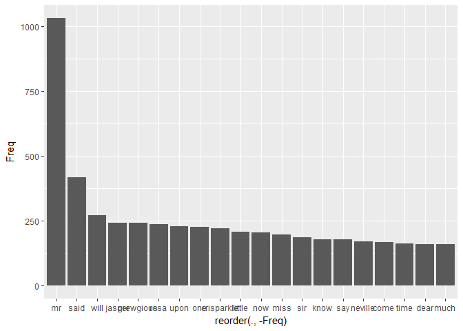

```r
###

TheMysteryOfEdwinDrood1 = TheMysteryOfEdwinDrood %>%

  str_replace_all("\"","") %>%
  str_replace_all("[[:punct:]]","") %>%
  str_split(pattern = "\\s") %>%
  unlist() %>%
  str_to_lower() %>%
  removeWords(., stopwords('en')) %>%
  str_trim() %>%
  table() %>%
  as.data.frame(stringsAsFactors = F)

TheMysteryOfEdwinDrood1 %>% arrange(-Freq) -> TheMysteryOfEdwinDrood1
r = TheMysteryOfEdwinDrood1[3:22 ,]
ggplot(r , aes(x = reorder(. , -Freq) , y = Freq)) + geom_col()
```

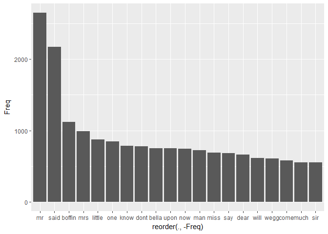

```r
###

OurMutualFriend1 = OurMutualFriend %>%

  str_replace_all("\"","") %>%
  str_replace_all("[[:punct:]]","") %>%
  str_split(pattern = "\\s") %>%
  unlist() %>%
  str_to_lower() %>%
  removeWords(., stopwords('en')) %>%
  str_trim() %>%
  table() %>%
  as.data.frame(stringsAsFactors = F)

OurMutualFriend1 %>% arrange(-Freq) -> OurMutualFriend1
r = OurMutualFriend1[3:22 ,]
ggplot(r , aes(x = reorder(. , -Freq) , y = Freq)) + geom_col()
```

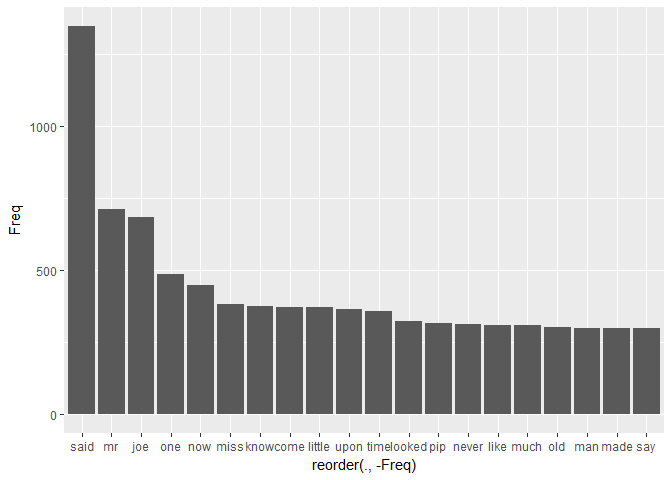

```r
###


GreatExpectations1 = GreatExpectations %>%

  str_replace_all("\"","") %>%
  str_replace_all("[[:punct:]]","") %>%
  str_split(pattern = "\\s") %>%
  unlist() %>%
  str_to_lower() %>%
  removeWords(., stopwords('en')) %>%
  str_trim() %>%
  table() %>%
  as.data.frame(stringsAsFactors = F)

GreatExpectations1 %>% arrange(-Freq) -> GreatExpectations1
r = GreatExpectations1[3:22 ,]
ggplot(r , aes(x = reorder(. , -Freq) , y = Freq)) + geom_col()
```

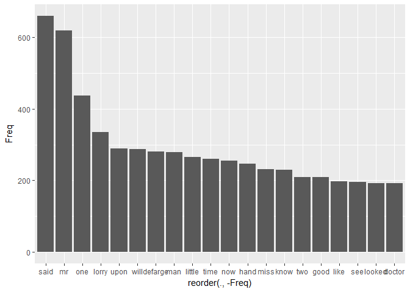

```r
###

ATaleOfTwoCities1 = ATaleOfTwoCities %>%

  str_replace_all("\"","") %>%
  str_replace_all("[[:punct:]]","") %>%
  str_split(pattern = "\\s") %>%
  unlist() %>%
  str_to_lower() %>%
  removeWords(., stopwords('en')) %>%
  str_trim() %>%
  table() %>%
  as.data.frame(stringsAsFactors = F)

ATaleOfTwoCities1 %>% arrange(-Freq) -> ATaleOfTwoCities1
r = ATaleOfTwoCities1[3:22 ,]
ggplot(r , aes(x = reorder(. , -Freq) , y = Freq)) + geom_col()
```

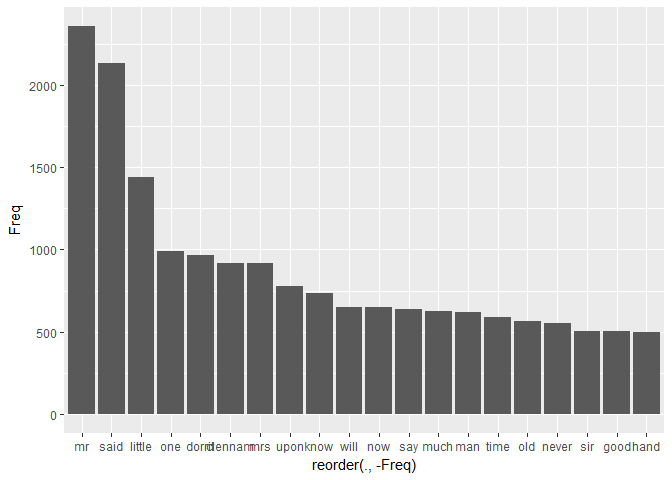

```r
###

LittleDorrit1 = LittleDorrit %>%

  str_replace_all("\"","") %>%
  str_replace_all("[[:punct:]]","") %>%
  str_split(pattern = "\\s") %>%
  unlist() %>%
  str_to_lower() %>%
  removeWords(., stopwords('en')) %>%
  str_trim() %>%
  table() %>%
  as.data.frame(stringsAsFactors = F)

LittleDorrit1 %>% arrange(-Freq) -> LittleDorrit1
r = LittleDorrit1[3:22 ,]
ggplot(r , aes(x = reorder(. , -Freq) , y = Freq)) + geom_col()
```

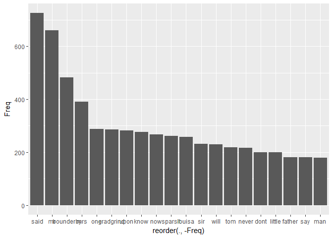

```r
###

HardTimes1 = HardTimes %>%

  str_replace_all("\"","") %>%
  str_replace_all("[[:punct:]]","") %>%
  str_split(pattern = "\\s") %>%
  unlist() %>%
  str_to_lower() %>%
  removeWords(., stopwords('en')) %>%
  str_trim() %>%
  table() %>%
  as.data.frame(stringsAsFactors = F)

HardTimes1 %>% arrange(-Freq) -> HardTimes1
r = HardTimes1[3:22 ,]
ggplot(r , aes(x = reorder(. , -Freq) , y = Freq)) + geom_col()
```

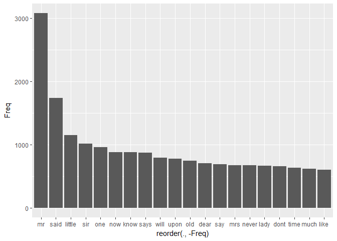

```r
###

BleakHouse1 = BleakHouse %>%

  str_replace_all("\"","") %>%
  str_replace_all("[[:punct:]]","") %>%
  str_split(pattern = "\\s") %>%
  unlist() %>%
  str_to_lower() %>%
  removeWords(., stopwords('en')) %>%
  str_trim() %>%
  table() %>%
  as.data.frame(stringsAsFactors = F)

BleakHouse1 %>% arrange(-Freq) -> BleakHouse1
r = BleakHouse1[3:22 ,]
ggplot(r , aes(x = reorder(. , -Freq) , y = Freq)) + geom_col()
```

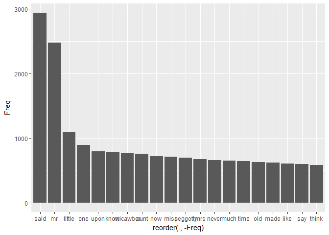

```r
###


DavidCopperfield1 = DavidCopperfield %>%

  str_replace_all("\"","") %>%
  str_replace_all("[[:punct:]]","") %>%
  str_split(pattern = "\\s") %>%
  unlist() %>%
  str_to_lower() %>%
  removeWords(., stopwords('en')) %>%
  str_trim() %>%
  table() %>%
  as.data.frame(stringsAsFactors = F)

DavidCopperfield1 %>% arrange(-Freq) -> DavidCopperfield1
r = DavidCopperfield1[3:22 ,]
ggplot(r , aes(x = reorder(. , -Freq) , y = Freq)) + geom_col()
```

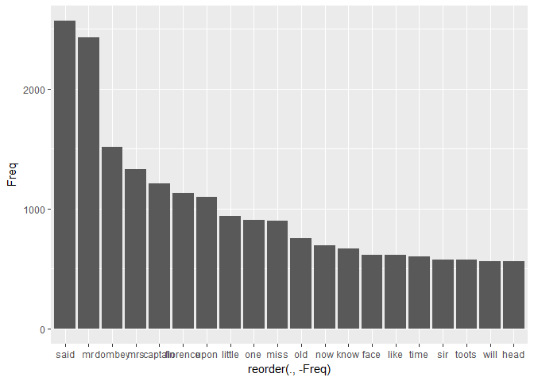

```r
###

DombeyandSon1 = DombeyandSon %>%

  str_replace_all("\"","") %>%
  str_replace_all("[[:punct:]]","") %>%
  str_split(pattern = "\\s") %>%
  unlist() %>%
  str_to_lower() %>%
  removeWords(., stopwords('en')) %>%
  str_trim() %>%
  table() %>%
  as.data.frame(stringsAsFactors = F)

DombeyandSon1 %>% arrange(-Freq) -> DombeyandSon1
r = DombeyandSon1[3:22 ,]
ggplot(r , aes(x = reorder(. , -Freq) , y = Freq)) + geom_col()
```

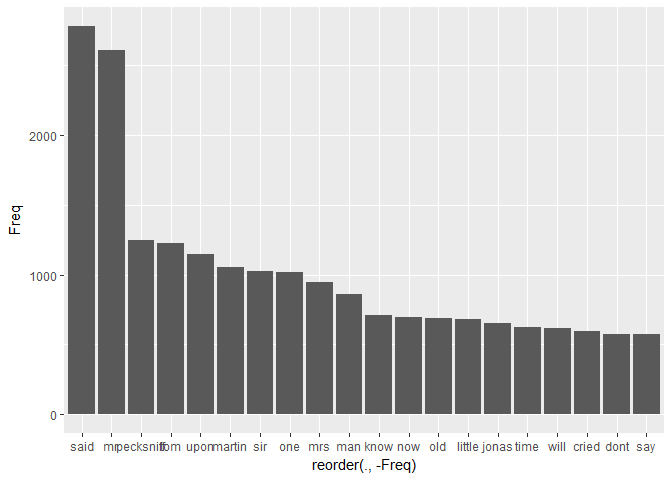

```r
###

MartinChuzzlewit1 = MartinChuzzlewit %>%

  str_replace_all("\"","") %>%
  str_replace_all("[[:punct:]]","") %>%
  str_split(pattern = "\\s") %>%
  unlist() %>%
  str_to_lower() %>%
  removeWords(., stopwords('en')) %>%
  str_trim() %>%
  table() %>%
  as.data.frame(stringsAsFactors = F)

MartinChuzzlewit1 %>% arrange(-Freq) -> MartinChuzzlewit1
r = MartinChuzzlewit1[3:22 ,]
ggplot(r , aes(x = reorder(. , -Freq) , y = Freq)) + geom_col()
```

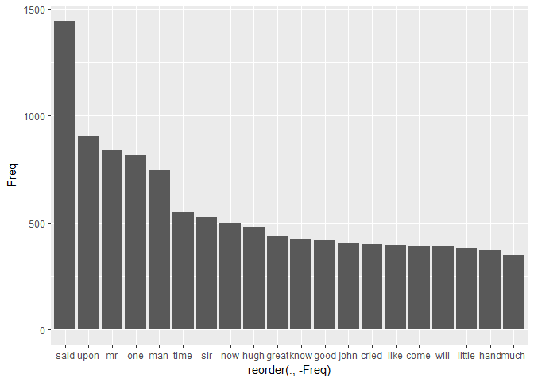

```r
###

BarnabyRudge1 = BarnabyRudge %>%

  str_replace_all("\"","") %>%
  str_replace_all("[[:punct:]]","") %>%
  str_split(pattern = "\\s") %>%
  unlist() %>%
  str_to_lower() %>%
  removeWords(., stopwords('en')) %>%
  str_trim() %>%
  table() %>%
  as.data.frame(stringsAsFactors = F)

BarnabyRudge1 %>% arrange(-Freq) -> BarnabyRudge1
r = BarnabyRudge1[3:22 ,]
ggplot(r , aes(x = reorder(. , -Freq) , y = Freq)) + geom_col()
```

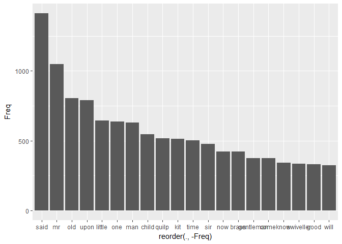

```r
###

TheOldCurisityShop1 = TheOldCurisityShop %>%

  str_replace_all("\"","") %>%
  str_replace_all("[[:punct:]]","") %>%
  str_split(pattern = "\\s") %>%
  unlist() %>%
  str_to_lower() %>%
  removeWords(., stopwords('en')) %>%
  str_trim() %>%
  table() %>%
  as.data.frame(stringsAsFactors = F)

TheOldCurisityShop1 %>% arrange(-Freq) -> TheOldCurisityShop1
r = TheOldCurisityShop1[3:22 ,]
ggplot(r , aes(x = reorder(. , -Freq) , y = Freq)) + geom_col()
```

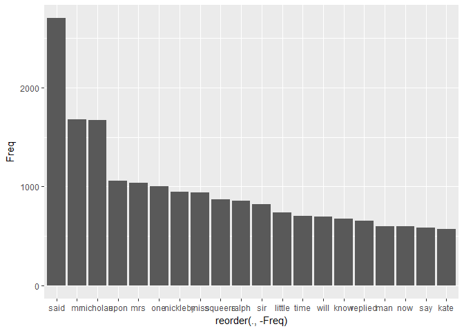

```r
###
NicholasNickleby1 = NicholasNickleby %>%

  str_replace_all("\"","") %>%
  str_replace_all("[[:punct:]]","") %>%
  str_split(pattern = "\\s") %>%
  unlist() %>%
  str_to_lower() %>%
  removeWords(., stopwords('en')) %>%
  str_trim() %>%
  table() %>%
  as.data.frame(stringsAsFactors = F)

NicholasNickleby1 %>% arrange(-Freq) -> NicholasNickleby1
r = NicholasNickleby1[3:22 ,]
ggplot(r , aes(x = reorder(. , -Freq) , y = Freq)) + geom_col()
```

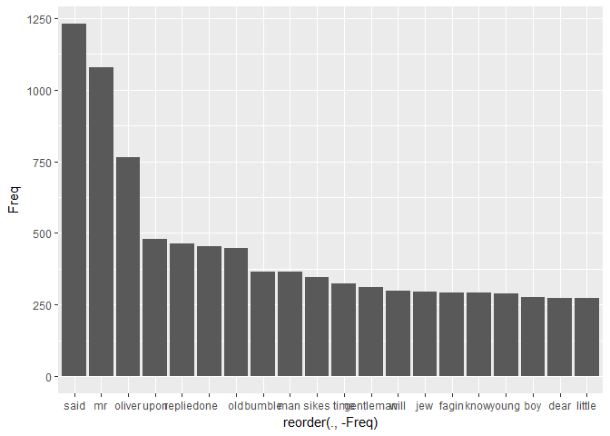

```r
###


OliverTwist1 = OliverTwist %>%

  str_replace_all("\"","") %>%
  str_replace_all("[[:punct:]]","") %>%
  str_split(pattern = "\\s") %>%
  unlist() %>%
  str_to_lower() %>%
  removeWords(., stopwords('en')) %>%
  str_trim() %>%
  table() %>%
  as.data.frame(stringsAsFactors = F)

OliverTwist1 %>% arrange(-Freq) -> OliverTwist1
r = OliverTwist1[3:22 ,]
ggplot(r , aes(x = reorder(. , -Freq) , y = Freq)) + geom_col()
```

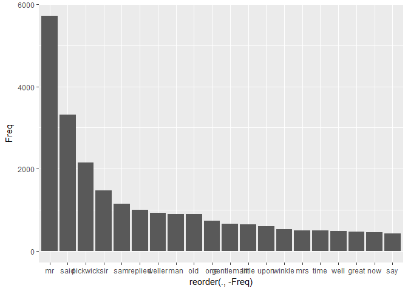

```r
###
ThePickwickPapers1 = ThePickwickPapers %>%

  str_replace_all("\"","") %>%
  str_replace_all("[[:punct:]]","") %>%
  str_split(pattern = "\\s") %>%
  unlist() %>%
  str_to_lower() %>%
  removeWords(., stopwords('en')) %>%
  str_trim() %>%
  table() %>%
  as.data.frame(stringsAsFactors = F)

ThePickwickPapers1 %>% arrange(-Freq) -> ThePickwickPapers1
r = ThePickwickPapers1[3:22 ,]
ggplot(r , aes(x = reorder(. , -Freq) , y = Freq)) + geom_col()
```

```r
###
```

۲. ابر لغات ۲۰۰ کلمه پرتکرار در رمان های چارلز دیکنز را رسم نمایید. این کار را با بسته wordcloud2 انجام دهید. برای دانلود می توانید به لینک زیر مراجعه کنید.

https://github.com/Lchiffon/wordcloud2

شکل مورد مظر را هم پرنده توییتر گرفتیم.

```r
TheMysteryOfEdwinDrood1 %>% arrange(-Freq) -> TheMysteryOfEdwinDrood1
r = TheMysteryOfEdwinDrood1[3:1000 ,]



wordcloud2(r, figPath = "D:/University/Semester8/Data analysis/week8/hw_08/images/download.png", size = 2,color = "skyblue")
```

[interactive chart not shown]

```r
OurMutualFriend1 %>% arrange(-Freq) -> OurMutualFriend1
r = OurMutualFriend1[3:1000 ,]

wordcloud2(r, figPath = "D:/University/Semester8/Data analysis/week8/hw_08/images/download.png", size = 2,color = "skyblue")
```

[interactive chart not shown]

```r
GreatExpectations1 %>% arrange(-Freq) -> GreatExpectations1
r = GreatExpectations1[3:1000 ,]


wordcloud2(r, figPath = "D:/University/Semester8/Data analysis/week8/hw_08/images/download.png", size = 2,color = "skyblue")
```

[interactive chart not shown]

```r
ATaleOfTwoCities1 %>% arrange(-Freq) -> ATaleOfTwoCities1
r = ATaleOfTwoCities1[3:1000 ,]



wordcloud2(r, figPath = "D:/University/Semester8/Data analysis/week8/hw_08/images/download.png", size = 2,color = "skyblue")
```

[interactive chart not shown]

```r
LittleDorrit1 %>% arrange(-Freq) -> LittleDorrit1
r = LittleDorrit1[3:22 ,]

wordcloud2(r, figPath = "D:/University/Semester8/Data analysis/week8/hw_08/images/download.png", size = 2,color = "skyblue")
```

[interactive chart not shown]

```r
HardTimes1 %>% arrange(-Freq) -> HardTimes1
r = HardTimes1[3:1000 ,]


wordcloud2(r, figPath = "D:/University/Semester8/Data analysis/week8/hw_08/images/download.png", size = 2,color = "skyblue")
```

[interactive chart not shown]

```r
BleakHouse1 %>% arrange(-Freq) -> BleakHouse1
r = BleakHouse1[3:1000 ,]

wordcloud2(r, figPath = "D:/University/Semester8/Data analysis/week8/hw_08/images/download.png", size = 2,color = "skyblue")
```

[interactive chart not shown]

```r
DavidCopperfield1 %>% arrange(-Freq) -> DavidCopperfield1
r = DavidCopperfield1[3:1000 ,]

wordcloud2(r, figPath = "D:/University/Semester8/Data analysis/week8/hw_08/images/download.png", size = 2,color = "skyblue")
```

[interactive chart not shown]

```r
DombeyandSon1 %>% arrange(-Freq) -> DombeyandSon1
r = DombeyandSon1[3:1000 ,]

wordcloud2(r, figPath = "D:/University/Semester8/Data analysis/week8/hw_08/images/download.png", size = 2,color = "skyblue")
```

[interactive chart not shown]

```r
MartinChuzzlewit1 %>% arrange(-Freq) -> MartinChuzzlewit1
r = MartinChuzzlewit1[3:1000 ,]
wordcloud2(r, figPath = "D:/University/Semester8/Data analysis/week8/hw_08/images/download.png", size = 2,color = "skyblue")
```

[interactive chart not shown]

```r
BarnabyRudge1 %>% arrange(-Freq) -> BarnabyRudge1
r = BarnabyRudge1[3:1000 ,]

wordcloud2(r, figPath = "D:/University/Semester8/Data analysis/week8/hw_08/images/download.png", size = 2,color = "skyblue")
```

[interactive chart not shown]

```r
TheOldCurisityShop1 %>% arrange(-Freq) -> TheOldCurisityShop1
r = TheOldCurisityShop1[3:1000 ,]


wordcloud2(r, figPath = "D:/University/Semester8/Data analysis/week8/hw_08/images/download.png", size = 2,color = "skyblue")
```

[interactive chart not shown]

```r
NicholasNickleby1 %>% arrange(-Freq) -> NicholasNickleby1
r = NicholasNickleby1[3:1000 ,]
wordcloud2(r, figPath = "D:/University/Semester8/Data analysis/week8/hw_08/images/download.png", size = 2,color = "skyblue")
```

[interactive chart not shown]

```r
OliverTwist1 %>% arrange(-Freq) -> OliverTwist1
r = OliverTwist1[3:1000 ,]
wordcloud2(r, figPath = "D:/University/Semester8/Data analysis/week8/hw_08/images/download.png", size = 2,color = "skyblue")
```

[interactive chart not shown]

```r
ThePickwickPapers1 %>% arrange(-Freq) -> ThePickwickPapers1
r = ThePickwickPapers1[3:1000 ,]

wordcloud2(r, figPath = "D:/University/Semester8/Data analysis/week8/hw_08/images/download.png", size = 2,color = "skyblue")
```

[interactive chart not shown]

***

۳. اسم پنج شخصیت اصلی در هر رمان دیکنز را استخراج کنید و با نموداری تعداد دفعات تکرار شده بر حسب رمان را رسم نمایید. (مانند مثال کلاس در رسم اسامی شخصیت ها در سری هر پاتر)

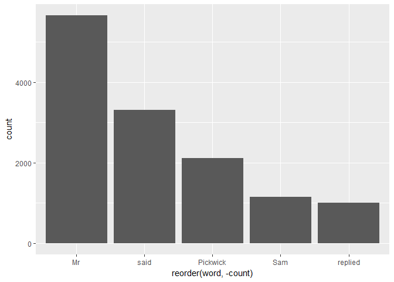

```r
  wstone = ThePickwickPapers %>%
    str_replace_all("\"","") %>%
    str_replace_all("[[:punct:]]","") %>%
    str_split(pattern = "\\s") %>%
    unlist() %>%
    table() %>%
    as.data.frame(stringsAsFactors = F)
  colnames(wstone) = c("word","count")


  wstone = wstone %>%
    filter(!str_to_lower(word) %in% stopwords('en')) %>%
    filter(str_length(word)>1) %>%
    filter(!str_detect(word,"\\d")) %>%
    arrange(desc(count)) %>%
    mutate(proper = !word %in% str_to_lower(word))



ggplot(data = wstone[1:5,], aes(reorder(word, -count), y = count)) + geom_bar(stat = 'identity',na.rm = TRUE)
```

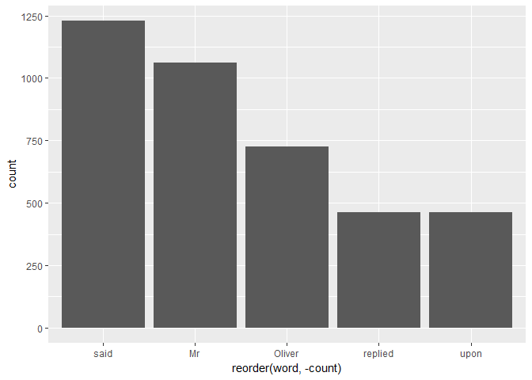

```r
  wstone = OliverTwist %>%
    str_replace_all("\"","") %>%
    str_replace_all("[[:punct:]]","") %>%
    str_split(pattern = "\\s") %>%
    unlist() %>%
    table() %>%
    as.data.frame(stringsAsFactors = F)
  colnames(wstone) = c("word","count")


  wstone = wstone %>%
    filter(!str_to_lower(word) %in% stopwords('en')) %>%
    filter(str_length(word)>1) %>%
    filter(!str_detect(word,"\\d")) %>%
    arrange(desc(count)) %>%
    mutate(proper = !word %in% str_to_lower(word))



ggplot(data = wstone[1:5,], aes(reorder(word, -count), y = count)) + geom_bar(stat = 'identity',na.rm = TRUE)
```

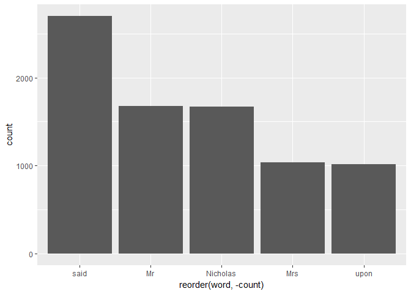

```r
  wstone = NicholasNickleby %>%
    str_replace_all("\"","") %>%
    str_replace_all("[[:punct:]]","") %>%
    str_split(pattern = "\\s") %>%
    unlist() %>%
    table() %>%
    as.data.frame(stringsAsFactors = F)
  colnames(wstone) = c("word","count")


  wstone = wstone %>%
    filter(!str_to_lower(word) %in% stopwords('en')) %>%
    filter(str_length(word)>1) %>%
    filter(!str_detect(word,"\\d")) %>%
    arrange(desc(count)) %>%
    mutate(proper = !word %in% str_to_lower(word))



ggplot(data = wstone[1:5,], aes(reorder(word, -count), y = count)) + geom_bar(stat = 'identity',na.rm = TRUE)
```

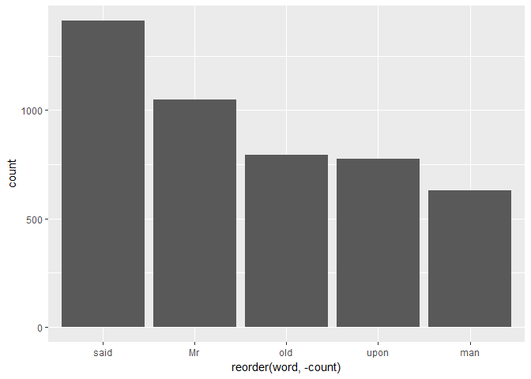

```r
  wstone = TheOldCurisityShop %>%
    str_replace_all("\"","") %>%
    str_replace_all("[[:punct:]]","") %>%
    str_split(pattern = "\\s") %>%
    unlist() %>%
    table() %>%
    as.data.frame(stringsAsFactors = F)
  colnames(wstone) = c("word","count")


  wstone = wstone %>%
    filter(!str_to_lower(word) %in% stopwords('en')) %>%
    filter(str_length(word)>1) %>%
    filter(!str_detect(word,"\\d")) %>%
    arrange(desc(count)) %>%
    mutate(proper = !word %in% str_to_lower(word))



ggplot(data = wstone[1:5,], aes(reorder(word, -count), y = count)) + geom_bar(stat = 'identity',na.rm = TRUE)
```

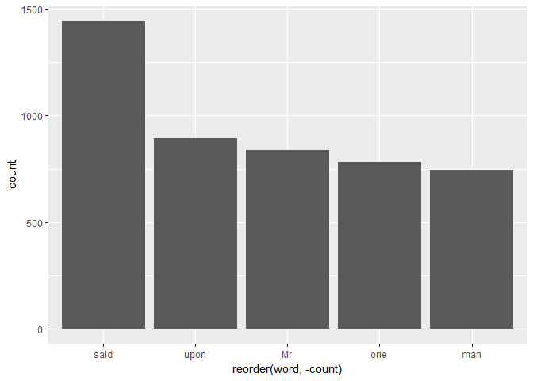

```r
  wstone = BarnabyRudge %>%
    str_replace_all("\"","") %>%
    str_replace_all("[[:punct:]]","") %>%
    str_split(pattern = "\\s") %>%
    unlist() %>%
    table() %>%
    as.data.frame(stringsAsFactors = F)
  colnames(wstone) = c("word","count")


  wstone = wstone %>%
    filter(!str_to_lower(word) %in% stopwords('en')) %>%
    filter(str_length(word)>1) %>%
    filter(!str_detect(word,"\\d")) %>%
    arrange(desc(count)) %>%
    mutate(proper = !word %in% str_to_lower(word))



ggplot(data = wstone[1:5,], aes(reorder(word, -count), y = count)) + geom_bar(stat = 'identity',na.rm = TRUE)
```

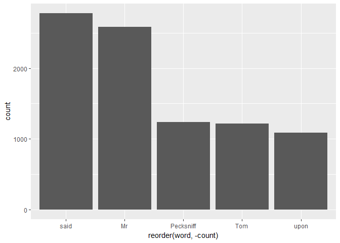

```r
  wstone = MartinChuzzlewit %>%
    str_replace_all("\"","") %>%
    str_replace_all("[[:punct:]]","") %>%
    str_split(pattern = "\\s") %>%
    unlist() %>%
    table() %>%
    as.data.frame(stringsAsFactors = F)
  colnames(wstone) = c("word","count")


  wstone = wstone %>%
    filter(!str_to_lower(word) %in% stopwords('en')) %>%
    filter(str_length(word)>1) %>%
    filter(!str_detect(word,"\\d")) %>%
    arrange(desc(count)) %>%
    mutate(proper = !word %in% str_to_lower(word))



ggplot(data = wstone[1:5,], aes(reorder(word, -count), y = count)) + geom_bar(stat = 'identity',na.rm = TRUE)
```

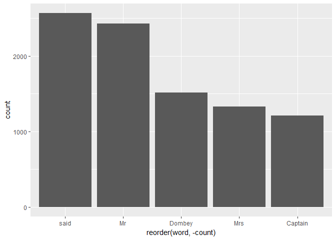

```r
  wstone = DombeyandSon %>%
    str_replace_all("\"","") %>%
    str_replace_all("[[:punct:]]","") %>%
    str_split(pattern = "\\s") %>%
    unlist() %>%
    table() %>%
    as.data.frame(stringsAsFactors = F)
  colnames(wstone) = c("word","count")


  wstone = wstone %>%
    filter(!str_to_lower(word) %in% stopwords('en')) %>%
    filter(str_length(word)>1) %>%
    filter(!str_detect(word,"\\d")) %>%
    arrange(desc(count)) %>%
    mutate(proper = !word %in% str_to_lower(word))



ggplot(data = wstone[1:5,], aes(reorder(word, -count), y = count)) + geom_bar(stat = 'identity',na.rm = TRUE)
```

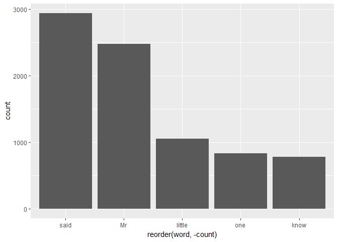

```r
  wstone = DavidCopperfield %>%
    str_replace_all("\"","") %>%
    str_replace_all("[[:punct:]]","") %>%
    str_split(pattern = "\\s") %>%
    unlist() %>%
    table() %>%
    as.data.frame(stringsAsFactors = F)
  colnames(wstone) = c("word","count")


  wstone = wstone %>%
    filter(!str_to_lower(word) %in% stopwords('en')) %>%
    filter(str_length(word)>1) %>%
    filter(!str_detect(word,"\\d")) %>%
    arrange(desc(count)) %>%
    mutate(proper = !word %in% str_to_lower(word))



ggplot(data = wstone[1:5,], aes(reorder(word, -count), y = count)) + geom_bar(stat = 'identity',na.rm = TRUE)
```

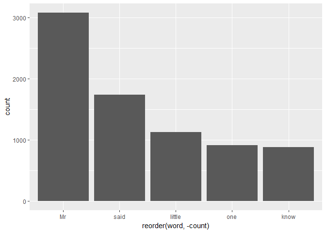

```r
  wstone = BleakHouse %>%
    str_replace_all("\"","") %>%
    str_replace_all("[[:punct:]]","") %>%
    str_split(pattern = "\\s") %>%
    unlist() %>%
    table() %>%
    as.data.frame(stringsAsFactors = F)
  colnames(wstone) = c("word","count")


  wstone = wstone %>%
    filter(!str_to_lower(word) %in% stopwords('en')) %>%
    filter(str_length(word)>1) %>%
    filter(!str_detect(word,"\\d")) %>%
    arrange(desc(count)) %>%
    mutate(proper = !word %in% str_to_lower(word))



ggplot(data = wstone[1:5,], aes(reorder(word, -count), y = count)) + geom_bar(stat = 'identity',na.rm = TRUE)
```

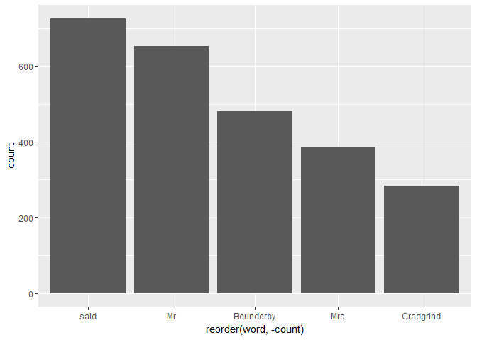

```r
  wstone = HardTimes %>%
    str_replace_all("\"","") %>%
    str_replace_all("[[:punct:]]","") %>%
    str_split(pattern = "\\s") %>%
    unlist() %>%
    table() %>%
    as.data.frame(stringsAsFactors = F)
  colnames(wstone) = c("word","count")


  wstone = wstone %>%
    filter(!str_to_lower(word) %in% stopwords('en')) %>%
    filter(str_length(word)>1) %>%
    filter(!str_detect(word,"\\d")) %>%
    arrange(desc(count)) %>%
    mutate(proper = !word %in% str_to_lower(word))



ggplot(data = wstone[1:5,], aes(reorder(word, -count), y = count)) + geom_bar(stat = 'identity',na.rm = TRUE)
```

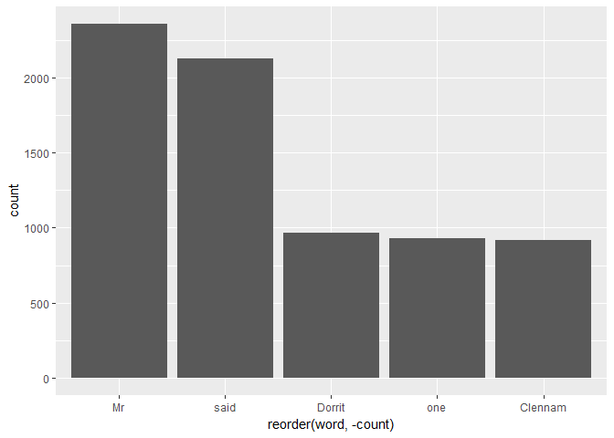

```r
  wstone = LittleDorrit %>%
    str_replace_all("\"","") %>%
    str_replace_all("[[:punct:]]","") %>%
    str_split(pattern = "\\s") %>%
    unlist() %>%
    table() %>%
    as.data.frame(stringsAsFactors = F)
  colnames(wstone) = c("word","count")


  wstone = wstone %>%
    filter(!str_to_lower(word) %in% stopwords('en')) %>%
    filter(str_length(word)>1) %>%
    filter(!str_detect(word,"\\d")) %>%
    arrange(desc(count)) %>%
    mutate(proper = !word %in% str_to_lower(word))



ggplot(data = wstone[1:5,], aes(reorder(word, -count), y = count)) + geom_bar(stat = 'identity',na.rm = TRUE)
```